# Project Disney+ Intro to Statistics and Data Analysis with R

Dana Braynin 207106865, Inbar Rodan 319058251

## Background

This project is based on data from [“Kaggle”](https://www.kaggle.com/) that called [“Disney+ TV Shows and Movies”](https://www.kaggle.com/datasets/victorsoeiro/disney-tv-shows-and-movies). This data set was created to list all shows available on Disney+ streaming and analyze the data to find interesting facts. This data was acquired in May 2022 containing data available in the United States.

This data set has two files containing the titles (titles.csv) and the cast (credits.csv) for the title. We chose to focus on the titles.csv data.

[Disney](https://thewaltdisneycompany.com/) was originally founded in 1923, by the two Disney brothers. The company established itself as a leader in the American animation industry before diversifying into live-action film production, television, and theme parks. One of the subsidiaries of Disney is Disney+. It is an American subscription video on-demand over-the-top streaming service.

[figure not shown]

## Data Import

First, We load the relevant libraries.

```r
library("tidyverse")  #main package
library("ggplot2") # for graphs
library(corrplot) # for correlation check
library(kableExtra) # for kable design
library(ggpmisc) # for table in plot
library(cowplot) # for putting plots together
```

Second, we read the file with read.csv function.

```r
Data_set <-read.csv("titles.csv")
```

We want to know the data and it’s content. To do so, we use the function glimpse().

```r
glimpse(Data_set)
```

```
## Rows: 1,535
## Columns: 15
## $ id                   <chr> "tm74391", "tm67803", "tm82546", "tm79357", "tm62~
## $ title                <chr> "Fantasia", "Snow White and the Seven Dwarfs", "P~
## $ type                 <chr> "MOVIE", "MOVIE", "MOVIE", "MOVIE", "MOVIE", "MOV~
## $ description          <chr> "Walt Disney's timeless masterpiece is an extrava~
## $ release_year         <int> 1940, 1937, 1940, 1942, 1950, 1949, 1950, 1941, 1~
## $ age_certification    <chr> "G", "G", "G", "G", "PG", "G", "G", "G", "G", "G"~
## $ runtime              <int> 120, 83, 88, 70, 96, 68, 74, 63, 71, 74, 73, 8, 4~
## $ genres               <chr> "['animation', 'family', 'music', 'fantasy']", "[~
## $ production_countries <chr> "['US']", "['US']", "['US']", "['US']", "['GB', '~
## $ seasons              <dbl> NA, NA, NA, NA, NA, NA, NA, NA, NA, NA, NA, NA, N~
## $ imdb_id              <chr> "tt0032455", "tt0029583", "tt0032910", "tt0034492~
## $ imdb_score           <dbl> 7.7, 7.6, 7.5, 7.3, 6.9, 6.9, 7.3, 7.2, 6.3, 6.8,~
## $ imdb_votes           <dbl> 94681, 195321, 141937, 140406, 8229, 15405, 15709~
## $ tmdb_popularity      <dbl> 57.751, 107.137, 71.160, 68.136, 10.698, 10.862, ~
## $ tmdb_score           <dbl> 7.4, 7.1, 7.1, 7.0, 6.5, 6.5, 7.0, 7.0, 6.4, 6.6,~
```

This data set contains 1500 unique titles on Disney+ with 15 columns containing their information, including:

```r
Titles <- c('ID','title','show type','description','release year','age certification','runtime','genres','production countries','seasons','IMDB ID','IMDB Score','IMDB Votes','TMDB Popularity','TMDB Score')
Information <- c('The title ID on JustWatch', 'The name of the title', 'TV show or movie', 'A brief description','The release year','The age certification','The length of the episode or movie','A list of genres','A list of countries that produced the title','Number of seasons if it is a SHOW','The title ID on IMDB','Score on IMDB','Votes on IMDB','Popularity on TMDB','Score on TMDB')

age_certification_type <- c('No certification', 'G', 'PG', 'PG-13', 'TV-14', 'TV-G', 'TV-MA', 'TV-PG', 'TV-Y', 'TV-Y7')
meanings <- c('No certification', 'General', 'Parental guidance - in the USA', 'Over 13', 'Over 14', 'Family content','Mature only','Parental guidance','Children of all ages','Over 7')

Content<-data.frame(Titles,Information)
Content_kable <- kable(Content, caption="Table of contents:")
data_meaning<-data.frame(age_certification_type,meanings)
data_meaning_kable <- kable(data_meaning, caption = "Table of age certification meanings")

kable(list(Content, data_meaning),  caption = "Table of contents (on the left) and age certification meanings (on the right)")
```

Table of contents (on the left) and age certification meanings (on the right)

| Titles | Information |
| --- | --- |
| ID | The title ID on JustWatch |
| title | The name of the title |
| show type | TV show or movie |
| description | A brief description |
| release year | The release year |
| age certification | The age certification |
| runtime | The length of the episode or movie |
| genres | A list of genres |
| production countries | A list of countries that produced the title |
| seasons | Number of seasons if it is a SHOW |
| IMDB ID | The title ID on IMDB |
| IMDB Score | Score on IMDB |
| IMDB Votes | Votes on IMDB |
| TMDB Popularity | Popularity on TMDB |
| TMDB Score | Score on TMDB |

| age_certification_type | meanings |
| --- | --- |
| No certification | No certification |
| G | General |
| PG | Parental guidance - in the USA |
| PG-13 | Over 13 |
| TV-14 | Over 14 |
| TV-G | Family content |
| TV-MA | Mature only |
| TV-PG | Parental guidance |
| TV-Y | Children of all ages |
| TV-Y7 | Over 7 |

## Introducing the research questions

In this project we will discuss two questions:

# The first one is hypothesis test

In this question we will focus on shows and movies that include “comedy” in their genres. We want to check the difference in means of the rating score in movies and shows.

Definitions: μ1 - the mean of the movie scores, μ2 - the mean of the show scores.

$$H_0: μ_1-μ_2 = 0$$
$$H_1: μ_1-μ_2 ≠ 0$$
In case we accept the alternative hypothesis, we will check which one is greater. This will tell us which type is preferred in the comedy genre- shows or movies.

# The second one is multiple linear regression

We want to analyze the influence of the independent variables: release year, number of seasons and runtime on the dependent variable which is popularity scores of shows only.

Definitions: β1- the coefficient of release year, β2- the coefficient of number of seasons, β3- the coefficient of run time.

$$H_0:β_1=β_2=β_3 = 0$$
$$H_1:Ǝi_{\text{ }} such_{\text{ }}that{\text{
}}β_i ≠ 0$$

In case we accept the alternative hypothesis, it means that one or more of the independent variables affects the popularity score of the shows.

## Visualizing

Using ggplot2, we will show distribution of variables and relationships between variables.

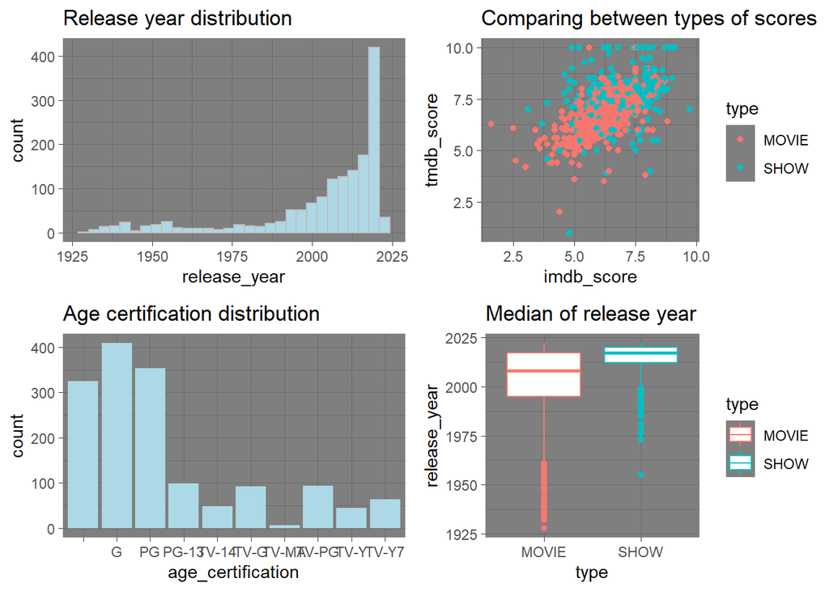

```r
compare_score_types <- ggplot(Data_set,aes(x=imdb_score,y= tmdb_score, color=type))+
  geom_point() +
  theme_dark()+
  labs(title = "Comparing between types of scores")

release_year_dist <- ggplot(Data_set,aes(release_year))+
  geom_histogram(color = "grey", fill="lightblue") +
  theme_dark()+
  labs(title = "Release year distribution")

age_certification_dist <- ggplot(Data_set, aes(age_certification)) +
  geom_bar(fill="lightblue") +
  theme_dark()+
  labs(title = "Age certification distribution")

median_release_year <- ggplot(data = Data_set, mapping = aes(x = type, y = release_year, color = type)) +
  geom_boxplot()+
  labs(title = "Median of release year")+
  theme_dark()

plot_grid(release_year_dist, compare_score_types, age_certification_dist, median_release_year)
```

## Hypothesis test - The difference in means

# Data Tidying

In order to analyze the first research question, we want to arrange the data set so it will include only relevant information.

We created a new data set for the first model which contains the following: type (MOVIE,SHOW), score (imdb_score) and genres (that include comedy).

Second, we deleted all the rows that contain missing information. In conclusion, we lost 970 samples.

```r
q1_data<-Data_set %>%
  select(title,type,genres,imdb_score) %>%
  rename(score=imdb_score) %>%
  mutate(comedy = str_detect(genres, "comedy")) %>%
  filter(comedy == "TRUE")%>%
  na.omit %>%
  select(-comedy)
```

# Modelling

One of the assumptions that needs to be made is **CLT** (Central Limit Theorem).

```r
kable(count(q1_data,type), col.names = c("Type", "Counter")) %>%
  kable_styling(full_width = F)
```

| Type | Counter |
| --- | --- |
| MOVIE | 390 |
| SHOW | 175 |

We can see that we have more than 30 samples in each type.

The result shows that there are 175 shows and 390 movies. That means that they are **unpaired** and because of that they are also **independent**.

In order to use t.test we need to **compare between the variance** of the scores for movies and the scores for shows.

```r
movies <- q1_data%>%
  filter(type == "MOVIE")
var_movie <- var(movies$score)

shows <- q1_data%>%
  filter(type == "SHOW")
var_show <- var(shows$score)

var_type <- c("Variance of movies", "Variance of shows")
var_result <- c(var_movie, var_show)
frame <- data.frame(var_type, var_result)
kable(frame, caption="Compare between variance:") %>%
  kable_styling(full_width = F)
```

Compare between variance:

| var_type | var_result |
| --- | --- |
| Variance of movies | 1.029366 |
| Variance of shows | 1.075105 |

We can see that the variances are not equal. The variance of shows is greater than the variance of movies.

In order to check the difference in means, we used the **t.test** function.

For reminder, the Null hypothesis is:
$$H_0: μ_1-μ_2 = 0$$
The alternative hypothesis is:
$$H_1: μ_1-μ_2 ≠
0$$

```r
t.test(formula=score~type, data = q1_data, paired = FALSE , var.equal = FALSE)
```

```
##
##  Welch Two Sample t-test
##
## data:  score by type
## t = -4.2431, df = 328.51, p-value = 2.871e-05
## alternative hypothesis: true difference in means between group MOVIE and group SHOW is not equal to 0
## 95 percent confidence interval:
##  -0.5820093 -0.2132874
## sample estimates:
## mean in group MOVIE  mean in group SHOW
##            6.186923            6.584571
```

# Visualization of the conclusion

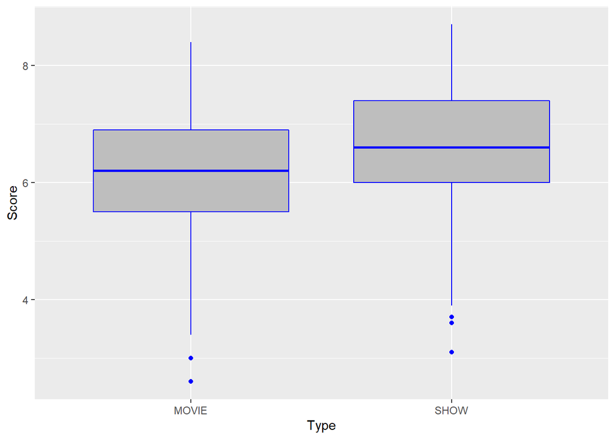

```r
ggplot(q1_data, aes(x=type, y=score))+
  geom_boxplot(color="blue", fill="gray")+
  labs(x="Type", y="Score")
```

As we can see from the graph and the t.test, the mean of the show scores (μ2) is greater than the mean of the movie scores (μ1).

# Communicating our findings

To summarize, we assume that people around the world prefer watching comedy in shows more than in movies.

As a result we recommend Disney+ to invest their resources in making comedy shows more than in making comedy movies. Yet, we see that the difference in means is very minor (0.397) and therefor we think that Disney+ should not neglect the comedy movies completely.

## Something extra

We decided to check the top 5 movies and shows that include the comedy genre.

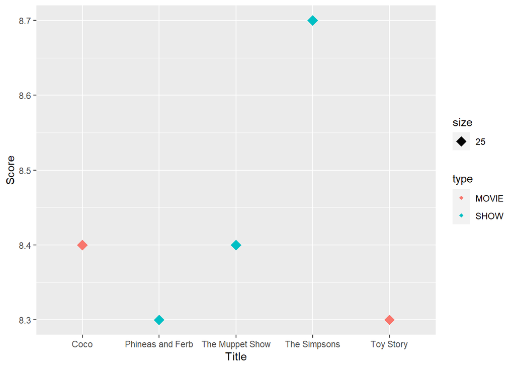

```r
data_sorted <- q1_data[order(q1_data$score, decreasing = TRUE),]
top_5 <- data_sorted%>%
  slice(1:5)

ggplot(top_5, aes(x=title, y=score, color=type, size=25))+
  geom_point(shape=18)+
  labs(x="Title", y="Score")
```

## And our top five are:

[figure not shown]

[figure not shown]

[figure not shown]

[figure not shown]

[figure not shown]

## Multiple linear regression

For reminder, the second question is multiple linear regression that checks the influence of the independent variables: release year, number of seasons and run time on the dependent variable which is popularity scores of shows only. According to independent variables, β1, β2 and β3 are their coefficients.

$$H_0:β_1=β_2=β_3 = 0$$
$$H_1:Ǝi_{\text{ }} such_{\text{ }}that{\text{
}}β_i ≠ 0$$

# Data Tidying

In order to analyze the second research question, we want to arrange the data set so it will include only relevant information.

We created a new data with the following: shows, release year, number of seasons, runtime and popularity score. We also deleted rows that contain missing information.

For reasons of proportion, we chose to leave only shows that their popularity score is under 400 and the number of their seasons is under 10. As a result, we lost 1136 samples.

```r
q2_data<-Data_set%>%
  select(type,release_year,seasons,runtime,tmdb_popularity)%>%
  rename(popularity=tmdb_popularity) %>%
  na.omit%>%
  select(-type)%>%
  filter(popularity < 400, seasons < 10)
```

# Modelling

First, we will perform multiple linear regression with **lm** function.

```r
q2_lm <- lm(formula=popularity ~ ., data=q2_data)
```

Second, we need to handle the **multicolinearity** between the variables with VIF (Variance Inflation Factor).

When using multiple variables, we need to check for correlations between the explanatory variables, otherwise, we might get misleading results.

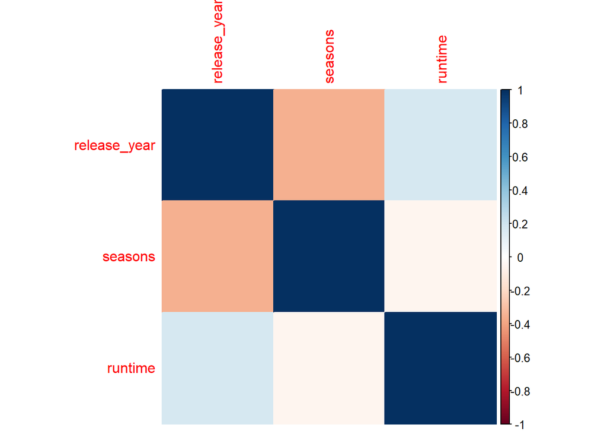

```r
cor_check <- q2_data %>%
  select(-popularity) %>%
  cor(use="pairwise.complete.obs")
corrplot(cor_check, method = 'color')
```

```r
kable(car::vif(q2_lm), caption = "VIF check") %>%
  kable_styling(full_width = F)
```

VIF check

|  | x |
| --- | --- |
| release_year | 1.179517 |
| seasons | 1.146216 |
| runtime | 1.032442 |

As we can see, the correlations between the variables are not equal to 1 and none of the VIF is bigger than 5, which means that they do not affect one another and we can keep all of them.

After that, we want to check if the error, **residuals**, of the multiple linear regression is normally distributed.

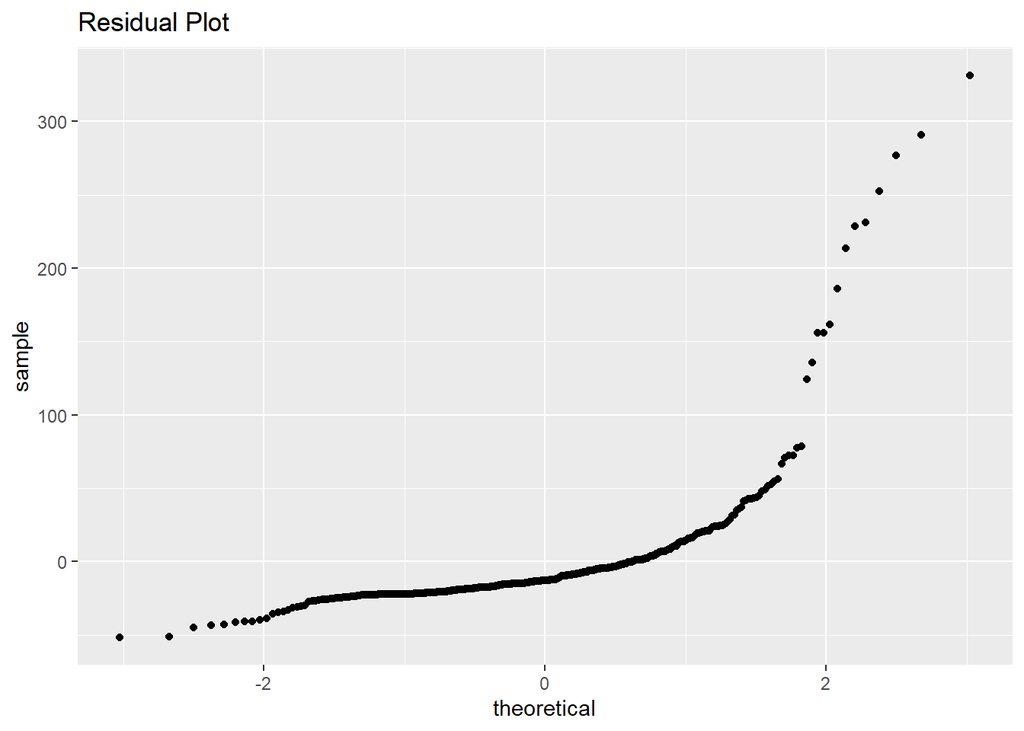

```r
lm_tibble<- tibble(res=q2_lm$residuals,
       fitted=q2_lm$fitted.values,
       ovral =q2_lm$model$popularity)
ggplot(data = lm_tibble, aes(sample = res))+
  geom_qq() +
  labs(title = "Residual Plot")
```

As the graph shows, the error (res) is not normally distributed. For the case of this project, we will assume that it is normally distributed.

And now, we will check if **homoscedasticity** exists.

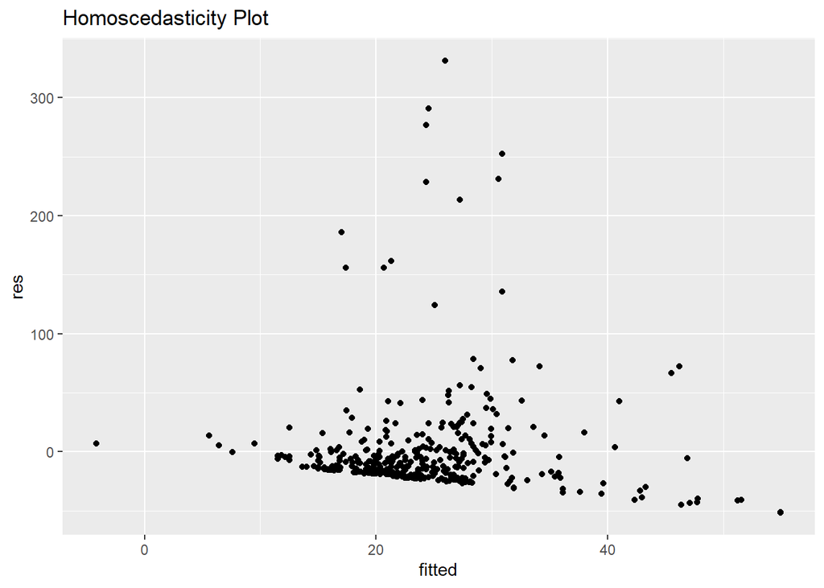

```r
ggplot(data= lm_tibble,aes(y=res, x=fitted))+
         geom_point() +
  labs(title = "Homoscedasticity Plot")
```

As the graph shows, the error (res) is not homoscedastic. For the case of this project, we will assume that it is homoscedastic.

# Visualization of the conclusion

After we checked all of the assumptions, we can check the numeric parameters and the summary of the multiple linear regression:

```r
summary(q2_lm)
```

```
##
## Call:
## lm(formula = popularity ~ ., data = q2_data)
##
## Residuals:
##    Min     1Q Median     3Q    Max
## -51.46 -20.00 -12.84   1.32 331.49
##
## Coefficients:
##               Estimate Std. Error t value Pr(>|t|)
## (Intercept)  -674.2214   501.2604  -1.345  0.17938
## release_year    0.3395     0.2487   1.365  0.17293
## seasons         4.2061     1.4390   2.923  0.00367 **
## runtime         0.1737     0.1457   1.193  0.23376
## ---
## Signif. codes:  0 '***' 0.001 '**' 0.01 '*' 0.05 '.' 0.1 ' ' 1
##
## Residual standard error: 45.33 on 395 degrees of freedom
## Multiple R-squared:  0.02553,    Adjusted R-squared:  0.01813
## F-statistic:  3.45 on 3 and 395 DF,  p-value: 0.01671
```

We can learn a few things about this data from this summary:

The P-value is 0.01671 and α is 0.05. Since α is greater then p-value, it indicates that we have at least one coefficient in our model that is not zero. Therefor, it teaches us that the **null hypothesis should be rejected**. That means that Ǝi such that βi ≠ 0.

Now we want to find the i that leads to βi ≠ 0. We will check the column “Pr(>|t|)” in “Coefficients” and find the relevant p-value that is less then 0.05. **The relevant row is “seasons” because its p-value is 0.00367**.

We will check the column “Estimate” in “Coefficients”. This column shows us the value of β for each variable. As we showed, the relevant variable is “seasons” and its β is 4.2061. That means that there is a positive relationship between the variables, **for each season that is added, 4.2061 is added to the popularity score**.

In contrast, we can see that the Multiple R-squared is 0.02553. **This is very small Multiple R-squared**, which means that the model does not predict in a good way the dependent variable, popularity scores of shows.

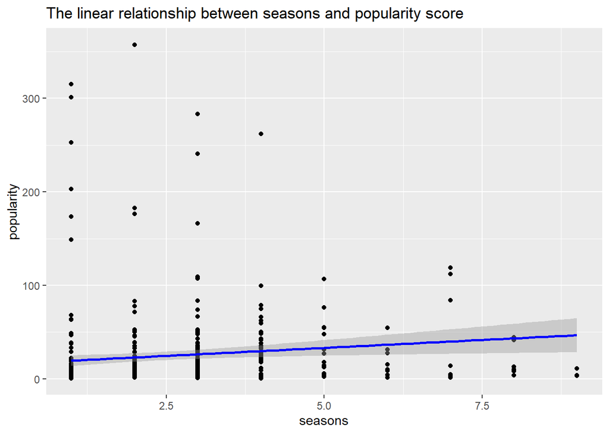

```r
ggplot(q2_lm, aes(x = seasons, y = popularity)) +
  geom_point() +
  stat_smooth(method = "lm", col = "blue") +
  labs(title = "The linear relationship between seasons and popularity score")
```

# Communicating our findings

To summarize, we assume that the number of seasons affects the show’s popularity among the viewers.

As a result we recommend Disney+ to invest their resources in making multiple number of seasons in shows in order to gain high popularity scores.

## Conclusions

To summarize, we learned a lot while researching the data via the research questions.

Few of the things we learned are that the comedy genre is more popular in shows more than in movies. We assume that it is because comedy allows vent after a long working day and it is easier and more accessible to watch comedy in a series with short episodes versus a long movie.

Furthermore, we learned that the runtime and release year do not affect the popularity of the show among the viewers. In contrast, we saw that the number of seasons in a show does affect its popularity. We assume this happens because series with many seasons allow viewers to connect with the characters and to the evolving plot.

*“When you’re curious, you find lots of interesting things to do.*” ~Walt Disney

[figure not shown]